# RETRASCORE temporal validation: 2020-2025

Comparison with the 2015-2019 cohort

2026-10-05

# 1 Aim and validation design

The original RETRASCORE is applied without re-estimating any coefficient. The historical cohort contains patients from 2015-2019, the period used in the article, and the new temporal cohort contains patients from 2020 onward. Only years no later than the year in which this report is run are accepted; this excludes impossible future dates.

The outcome is 30-day mortality. A score and predicted probability are calculated only when all 13 RETRASCORE predictors are available. Validation metrics additionally require a known 30-day outcome. No missing values are imputed.

The published logistic equation is used for predicted mortality. The integer score is calculated as described in the article: each shrunken regression coefficient is multiplied by two and rounded to the nearest integer. Published risk categories are also assigned to every patient with a calculable score.

Published RETRASCORE coefficients and integer points

| Predictor | Coefficient | Points |
| --- | --- | --- |
| Age <50 | 0.000 | 0 |
| Age 50-65 | 0.598 | 1 |
| Age 66-75 | 1.239 | 2 |
| Age >75 | 2.198 | 4 |
| PRECOAG | 0.349 | 1 |
| Pre-hospital intubation | 0.336 | 1 |
| High-risk mechanism | 0.662 | 1 |
| Normal pupils | 0.000 | 0 |
| Unilateral mydriasis | 0.950 | 2 |
| Bilateral mydriasis | 3.217 | 6 |
| GCS <=8 | 0.841 | 2 |
| MAIS head | 0.495 | 1 |
| MAIS thorax | -0.271 | -1 |
| Haemodynamic failure | 1.148 | 2 |
| Respiratory failure | 0.708 | 1 |
| Coagulopathy at 24 h | 0.567 | 1 |
| Mechanical ventilation | 0.580 | 1 |
| Massive haemorrhage | 0.452 | 1 |

# 2 Data checks and cohort definition

```r
model_variables <- c(
  "edad_categoria", "precoag", "iot_prehospitalaria",
  "mecanismo_alto_riesgo", "pupilas", "gcs_menor_igual_8",
  "mais_cabeza", "mais_torax", "fallo_hemodinamico",
  "fallo_respiratorio", "coagulopatia_24h",
  "ventilacion_mecanica", "hemorragia_masiva"
)
required_variables <- c("ano_trauma", "mortalidad_30d", model_variables)
missing_variables <- setdiff(required_variables, names(cohort))
if (length(missing_variables)) {
  stop("Missing required variables: ", paste(missing_variables, collapse = ", "))
}

check_binary <- function(x, variable_name) {
  observed <- unique(stats::na.omit(x))
  if (!all(observed %in% c(0, 1))) {
    stop("Variable '", variable_name, "' contains values other than 0, 1 or NA.")
  }
  as.integer(x)
}

binary_variables <- setdiff(
  model_variables,
  c("edad_categoria", "pupilas")
)
for (variable_name in binary_variables) {
  cohort[[variable_name]] <- check_binary(
    cohort[[variable_name]], variable_name
  )
}
cohort$mortalidad_30d <- check_binary(
  cohort$mortalidad_30d, "mortalidad_30d"
)

valid_age_levels <- c("<50", "50-65", "66-75", ">75")
unexpected_age <- setdiff(
  unique(stats::na.omit(as.character(cohort$edad_categoria))),
  valid_age_levels
)
if (length(unexpected_age)) {
  stop("Unexpected age categories: ", paste(unexpected_age, collapse = ", "))
}

valid_pupil_levels <- c(
  "normal", "midriasis unilateral", "midriasis bilateral"
)
unexpected_pupils <- setdiff(
  unique(stats::na.omit(as.character(cohort$pupilas))),
  valid_pupil_levels
)
if (length(unexpected_pupils)) {
  stop("Unexpected pupil categories: ", paste(unexpected_pupils, collapse = ", "))
}

current_year <- as.integer(format(Sys.Date(), "%Y"))
future_years <- sort(unique(cohort$ano_trauma[
  !is.na(cohort$ano_trauma) & cohort$ano_trauma > current_year
]))

analysis_cohort <- cohort %>%
  filter(
    !is.na(ano_trauma),
    ano_trauma >= 2015,
    ano_trauma <= current_year
  ) %>%
  mutate(
    period = case_when(
      ano_trauma >= 2015 & ano_trauma <= 2019 ~ "2015-2019",
      ano_trauma >= 2020 ~ "2020 onward",
      TRUE ~ NA_character_
    ),
    period = factor(period, levels = c("2015-2019", "2020 onward"))
  ) %>%
  filter(!is.na(period))

if (!nrow(analysis_cohort)) stop("No patients met the date criteria.")
if (any(table(analysis_cohort$period) == 0)) {
  stop("At least one comparison period has no patients.")
}

latest_new_year <- max(
  analysis_cohort$ano_trauma[analysis_cohort$period == "2020 onward"]
)
levels(analysis_cohort$period) <- c(
  "2015-2019", paste0("2020-", latest_new_year)
)
period_labels <- levels(analysis_cohort$period)
```

Date audit

| Item | Value |
| --- | --- |
| Rows in source RDS | 17925 |
| Rows in the two requested periods | 17916 |
| Latest included year | 2025 |
| Future/impossible years excluded | 2925 |

Cohort flow and complete-case denominators

| period | Patients | Known 30-day outcome | Complete RETRASCORE predictors | Complete predictors and outcome |
| --- | --- | --- | --- | --- |
| 2015-2019 | 8821 | 8814 | 8245 | 8239 |
| 2020-2025 | 9095 | 9092 | 8453 | 8450 |

# 3 Patient-level RETRASCORE

```r
age <- as.character(analysis_cohort$edad_categoria)
pupils <- as.character(analysis_cohort$pupilas)

score_components <- data.frame(
  age = unname(c("<50" = 0L, "50-65" = 1L, "66-75" = 2L, ">75" = 4L)[age]),
  precoag = analysis_cohort$precoag,
  prehospital_intubation = analysis_cohort$iot_prehospitalaria,
  high_risk_mechanism = analysis_cohort$mecanismo_alto_riesgo,
  pupils = unname(c(
    "normal" = 0L,
    "midriasis unilateral" = 2L,
    "midriasis bilateral" = 6L
  )[pupils]),
  gcs_le_8 = 2L * analysis_cohort$gcs_menor_igual_8,
  mais_head = analysis_cohort$mais_cabeza,
  mais_thorax = -analysis_cohort$mais_torax,
  haemodynamic_failure = 2L * analysis_cohort$fallo_hemodinamico,
  respiratory_failure = analysis_cohort$fallo_respiratorio,
  coagulopathy = analysis_cohort$coagulopatia_24h,
  mechanical_ventilation = analysis_cohort$ventilacion_mecanica,
  massive_haemorrhage = analysis_cohort$hemorragia_masiva
)

score_available <- complete.cases(score_components)
analysis_cohort$retrascore <- NA_integer_
analysis_cohort$retrascore[score_available] <- rowSums(
  score_components[score_available, , drop = FALSE]
)

linear_predictor <- rep(NA_real_, nrow(analysis_cohort))
linear_predictor[score_available] <- with(
  analysis_cohort[score_available, , drop = FALSE],
  -5.432 +
    0.598 * (edad_categoria == "50-65") +
    1.239 * (edad_categoria == "66-75") +
    2.198 * (edad_categoria == ">75") +
    0.349 * precoag +
    0.336 * iot_prehospitalaria +
    0.662 * mecanismo_alto_riesgo +
    0.950 * (pupilas == "midriasis unilateral") +
    3.217 * (pupilas == "midriasis bilateral") +
    0.841 * gcs_menor_igual_8 +
    0.495 * mais_cabeza -
    0.271 * mais_torax +
    1.148 * fallo_hemodinamico +
    0.708 * fallo_respiratorio +
    0.567 * coagulopatia_24h +
    0.580 * ventilacion_mecanica +
    0.452 * hemorragia_masiva
)
analysis_cohort$predicted_mortality <- plogis(linear_predictor)

risk_levels <- c(
  "Very low (<5)", "Low (5-6)", "Medium (7-8)",
  "High (9-11)", "Very high (12-13)", "Extreme (14+)"
)
analysis_cohort$risk_group <- cut(
  analysis_cohort$retrascore,
  breaks = c(-Inf, 4, 6, 8, 11, 13, Inf),
  labels = risk_levels,
  ordered_result = TRUE
)
analysis_cohort$score_display_group <- ifelse(
  is.na(analysis_cohort$retrascore),
  NA_character_,
  ifelse(
    analysis_cohort$retrascore >= 14,
    "14+",
    as.character(analysis_cohort$retrascore)
  )
)

# Preserve identifiers when present, but do not require a particular identifier.
identifier_candidates <- c("id_fila", "historia", "registro", "hospital")
identifier_variables <- intersect(identifier_candidates, names(analysis_cohort))
patient_results <- analysis_cohort %>%
  select(
    all_of(identifier_variables), ano_trauma, period, mortalidad_30d,
    all_of(model_variables), retrascore, score_display_group, risk_group,
    predicted_mortality
  )

utils::write.csv(
  patient_results,
  file.path(output_dir, "retrascore_patient_scores.csv"),
  row.names = FALSE,
  na = "",
  fileEncoding = "UTF-8"
)

stopifnot(
  all(is.na(analysis_cohort$retrascore) == !score_available),
  all(analysis_cohort$predicted_mortality[score_available] >= 0),
  all(analysis_cohort$predicted_mortality[score_available] <= 1)
)
```

The file `outputs_retrascore_2020_2025_validation/retrascore_patient_scores.csv` contains the RETRASCORE, published risk group, and predicted probability for every patient in both periods. Rows with an incomplete score retain `NA`, so missing data are explicit rather than silently treated as zero.

Patient-level score availability

| period | Patients | Score calculated | Score missing | Minimum score | Median score | Maximum score |
| --- | --- | --- | --- | --- | --- | --- |
| 2015-2019 | 8821 | 8245 | 576 | -1 | 3 | 20 |
| 2020-2025 | 9095 | 8453 | 642 | -1 | 3 | 20 |

# 4 Validation of the published equation

The primary validation uses the continuous predicted probability, not a re-fitted model or an arbitrary classification threshold. Discrimination is summarised by AUROC with a DeLong 95% confidence interval; overall accuracy by the Brier score; and calibration by mean predicted versus observed mortality, observed-to-expected deaths, calibration intercept, and calibration slope.

```r
evaluate_period <- function(data, period_name) {
  evaluable <- data %>%
    filter(!is.na(mortalidad_30d), !is.na(predicted_mortality))
  if (length(unique(evaluable$mortalidad_30d)) != 2L) {
    stop("Both outcome classes are required in ", period_name, ".")
  }

  roc_object <- pROC::roc(
    response = evaluable$mortalidad_30d,
    predictor = evaluable$predicted_mortality,
    levels = c(0, 1),
    direction = "<",
    quiet = TRUE
  )
  auc_ci <- as.numeric(pROC::ci.auc(roc_object, method = "delong"))
  lp <- qlogis(pmin(pmax(evaluable$predicted_mortality, 1e-12), 1 - 1e-12))
  calibration_intercept_model <- glm(
    evaluable$mortalidad_30d ~ 1,
    offset = lp,
    family = binomial(link = "logit")
  )
  calibration_slope_model <- glm(
    evaluable$mortalidad_30d ~ lp,
    family = binomial(link = "logit")
  )

  data.frame(
    Period = period_name,
    N = nrow(evaluable),
    Deaths = sum(evaluable$mortalidad_30d),
    `Observed mortality (%)` = 100 * mean(evaluable$mortalidad_30d),
    `Predicted mortality (%)` = 100 * mean(evaluable$predicted_mortality),
    `Observed/expected deaths` = sum(evaluable$mortalidad_30d) /
      sum(evaluable$predicted_mortality),
    AUROC = as.numeric(pROC::auc(roc_object)),
    `AUROC 95% CI lower` = auc_ci[1],
    `AUROC 95% CI upper` = auc_ci[3],
    Brier = mean(
      (evaluable$mortalidad_30d - evaluable$predicted_mortality)^2
    ),
    `Calibration intercept` = unname(coef(calibration_intercept_model)[1]),
    `Calibration slope` = unname(coef(calibration_slope_model)[2]),
    check.names = FALSE
  )
}

validation_results <- do.call(
  rbind,
  lapply(period_labels, function(period_name) {
    evaluate_period(
      analysis_cohort[analysis_cohort$period == period_name, , drop = FALSE],
      period_name
    )
  })
)
row.names(validation_results) <- NULL

utils::write.csv(
  validation_results,
  file.path(output_dir, "retrascore_validation_metrics.csv"),
  row.names = FALSE,
  fileEncoding = "UTF-8"
)

validation_display <- validation_results
validation_display$`AUROC (95% CI)` <- sprintf(
  "%.3f (%.3f-%.3f)",
  validation_display$AUROC,
  validation_display$`AUROC 95% CI lower`,
  validation_display$`AUROC 95% CI upper`
)
validation_display <- validation_display[, c(
  "Period", "N", "Deaths", "Observed mortality (%)",
  "Predicted mortality (%)", "Observed/expected deaths",
  "AUROC (95% CI)", "Brier", "Calibration intercept",
  "Calibration slope"
)]

knitr::kable(
  validation_display,
  digits = c(0, 0, 0, 2, 2, 3, 0, 3, 3, 3),
  caption = "Validation of the unchanged published RETRASCORE equation"
)
```

Validation of the unchanged published RETRASCORE equation

| Period | N | Deaths | Observed mortality (%) | Predicted mortality (%) | Observed/expected deaths | AUROC (95% CI) | Brier | Calibration intercept | Calibration slope |
| --- | --- | --- | --- | --- | --- | --- | --- | --- | --- |
| 2015-2019 | 8239 | 1067 | 12.95 | 11.68 | 1.109 | 0.925 (0.918-0.933) | 0.065 | 0.204 | 1.071 |
| 2020-2025 | 8450 | 1013 | 11.99 | 10.36 | 1.158 | 0.926 (0.918-0.933) | 0.063 | 0.276 | 1.070 |

For calibration, ideal values are an observed-to-expected ratio of 1, an intercept of 0, and a slope of 1. Lower Brier scores are better. These measures should be interpreted together with the cohort size and number of deaths.

## 4.1 Calibration by risk decile

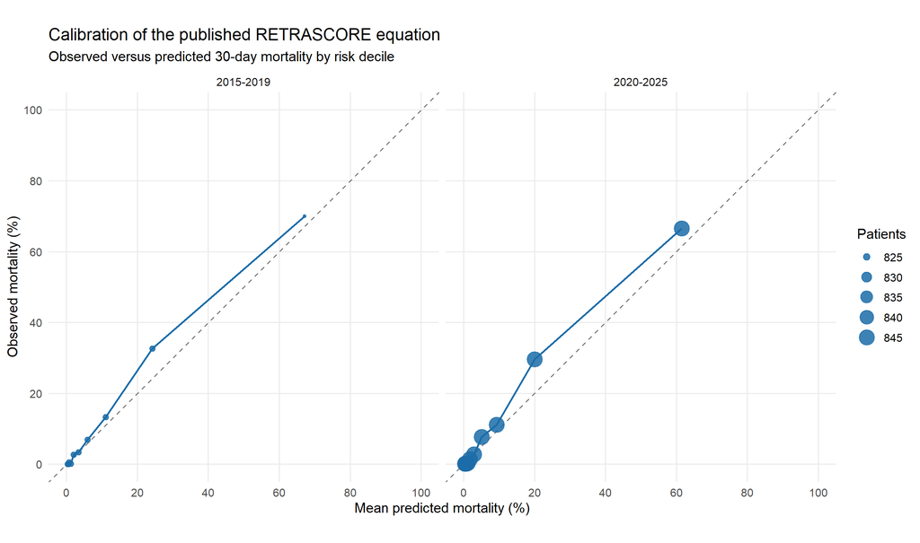

```r
calibration_deciles <- analysis_cohort %>%
  filter(!is.na(mortalidad_30d), !is.na(predicted_mortality)) %>%
  group_by(period) %>%
  mutate(risk_decile = dplyr::ntile(predicted_mortality, 10)) %>%
  group_by(period, risk_decile) %>%
  summarise(
    Patients = n(),
    predicted = mean(predicted_mortality),
    observed = mean(mortalidad_30d),
    .groups = "drop"
  )

calibration_plot <- ggplot(
  calibration_deciles,
  aes(x = predicted * 100, y = observed * 100)
) +
  geom_abline(intercept = 0, slope = 1, linetype = 2, colour = "grey45") +
  geom_line(colour = "#1B6CA8", linewidth = 0.8) +
  geom_point(aes(size = Patients), colour = "#1B6CA8", alpha = 0.85) +
  facet_wrap(~ period) +
  coord_equal(xlim = c(0, 100), ylim = c(0, 100)) +
  scale_x_continuous(breaks = seq(0, 100, 20)) +
  scale_y_continuous(breaks = seq(0, 100, 20)) +
  labs(
    title = "Calibration of the published RETRASCORE equation",
    subtitle = "Observed versus predicted 30-day mortality by risk decile",
    x = "Mean predicted mortality (%)",
    y = "Observed mortality (%)",
    size = "Patients"
  ) +
  theme_minimal(base_size = 12) +
  theme(panel.grid.minor = element_blank())

calibration_plot
```

```r
ggsave(
  file.path(output_dir, "retrascore_calibration_by_decile.png"),
  calibration_plot,
  width = 11,
  height = 6.5,
  dpi = 180
)
```

# 5 Mortality by RETRASCORE group

Exact binomial 95% confidence intervals are shown around the observed mortality. The denominator is the number of scored patients with a known 30-day outcome in each group.

```r
summarise_mortality <- function(data) {
  data %>%
    filter(!is.na(mortalidad_30d), !is.na(risk_group)) %>%
    group_by(period, risk_group, .drop = FALSE) %>%
    summarise(
      Patients = n(),
      Deaths = sum(mortalidad_30d),
      `Observed mortality (%)` = 100 * mean(mortalidad_30d),
      `Predicted mortality (%)` = 100 * mean(predicted_mortality),
      .groups = "drop"
    ) %>%
    rowwise() %>%
    mutate(
      `95% CI lower` = if (Patients > 0) {
        100 * stats::binom.test(Deaths, Patients)$conf.int[1]
      } else NA_real_,
      `95% CI upper` = if (Patients > 0) {
        100 * stats::binom.test(Deaths, Patients)$conf.int[2]
      } else NA_real_
    ) %>%
    ungroup()
}

mortality_by_group <- summarise_mortality(analysis_cohort)

utils::write.csv(
  mortality_by_group,
  file.path(output_dir, "mortality_by_retrascore_risk_group.csv"),
  row.names = FALSE,
  fileEncoding = "UTF-8"
)

knitr::kable(
  mortality_by_group,
  digits = c(0, 0, 0, 0, 2, 2, 2, 2),
  caption = "Observed and predicted mortality by published RETRASCORE risk group"
)
```

Observed and predicted mortality by published RETRASCORE risk group

| period | risk_group | Patients | Deaths | Observed mortality (%) | Predicted mortality (%) | 95% CI lower | 95% CI upper |
| --- | --- | --- | --- | --- | --- | --- | --- |
| 2015-2019 | Very low (<5) | 5124 | 71 | 1.39 | 1.55 | 1.08 | 1.74 |
| 2015-2019 | Low (5-6) | 1262 | 117 | 9.27 | 8.23 | 7.73 | 11.01 |
| 2015-2019 | Medium (7-8) | 845 | 225 | 26.63 | 19.71 | 23.67 | 29.74 |
| 2015-2019 | High (9-11) | 589 | 289 | 49.07 | 44.20 | 44.96 | 53.18 |
| 2015-2019 | Very high (12-13) | 184 | 138 | 75.00 | 72.99 | 68.10 | 81.08 |
| 2015-2019 | Extreme (14+) | 235 | 227 | 96.60 | 92.53 | 93.40 | 98.52 |
| 2020-2025 | Very low (<5) | 5499 | 80 | 1.45 | 1.55 | 1.16 | 1.81 |
| 2020-2025 | Low (5-6) | 1253 | 130 | 10.38 | 8.27 | 8.74 | 12.20 |
| 2020-2025 | Medium (7-8) | 816 | 235 | 28.80 | 19.50 | 25.71 | 32.04 |
| 2020-2025 | High (9-11) | 511 | 255 | 49.90 | 43.19 | 45.48 | 54.32 |
| 2020-2025 | Very high (12-13) | 191 | 153 | 80.10 | 73.46 | 73.73 | 85.52 |
| 2020-2025 | Extreme (14+) | 180 | 160 | 88.89 | 92.37 | 83.36 | 93.08 |

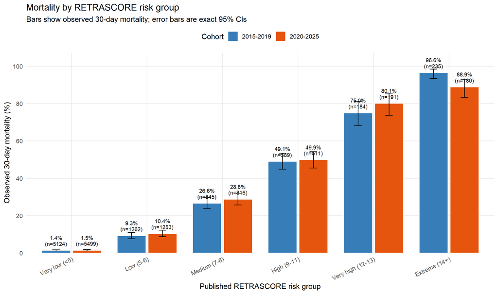

Observed 30-day mortality by published RETRASCORE risk group and period.

## 5.1 Predicted versus observed mortality in 2020-2025

This plot directly compares the mean mortality predicted by the unchanged published equation with the observed 30-day mortality in each RETRASCORE risk group in the new temporal cohort. Error bars around observed mortality are exact binomial 95% confidence intervals; predicted mortality is a model estimate and is therefore shown without those outcome-based intervals.

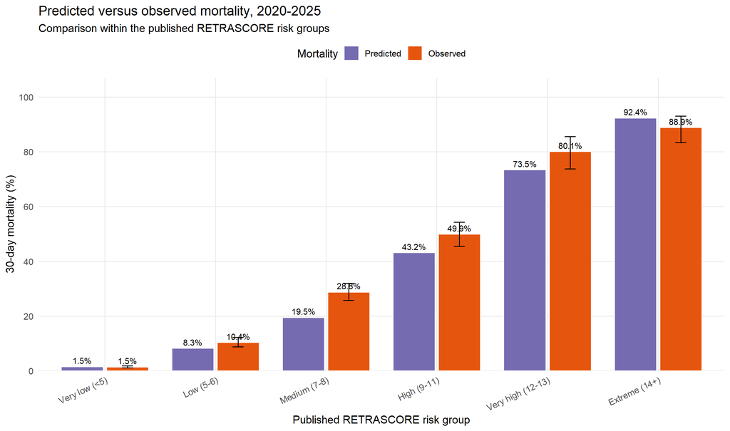

Predicted and observed 30-day mortality by RETRASCORE risk group in 2020-2025.

## 5.2 Mortality by exact RETRASCORE points

As in the article, scores above 13 are pooled because individual high scores contain few patients.

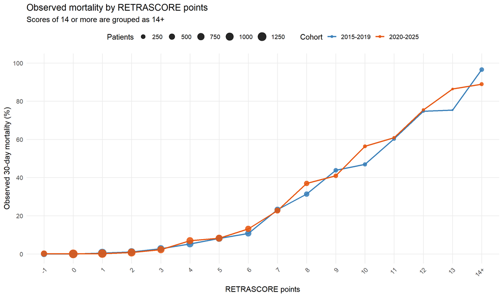

```r
score_levels_below_14 <- sort(unique(
  analysis_cohort$retrascore[
    !is.na(analysis_cohort$retrascore) & analysis_cohort$retrascore < 14
  ]
))
score_levels <- c(as.character(score_levels_below_14), "14+")
analysis_cohort$score_display_group <- factor(
  analysis_cohort$score_display_group,
  levels = score_levels,
  ordered = TRUE
)

mortality_by_score <- analysis_cohort %>%
  filter(!is.na(mortalidad_30d), !is.na(score_display_group)) %>%
  group_by(period, score_display_group, .drop = FALSE) %>%
  summarise(
    Patients = n(),
    Deaths = sum(mortalidad_30d),
    mortality_pct = 100 * mean(mortalidad_30d),
    .groups = "drop"
  ) %>%
  filter(Patients > 0)

utils::write.csv(
  mortality_by_score,
  file.path(output_dir, "mortality_by_exact_retrascore.csv"),
  row.names = FALSE,
  fileEncoding = "UTF-8"
)

mortality_score_plot <- ggplot(
  mortality_by_score,
  aes(
    x = score_display_group,
    y = mortality_pct,
    colour = period,
    group = period
  )
) +
  geom_line(linewidth = 0.9) +
  geom_point(aes(size = Patients), alpha = 0.85) +
  scale_colour_manual(values = c("#377EB8", "#E6550D")) +
  scale_y_continuous(
    limits = c(0, 100),
    breaks = seq(0, 100, 20)
  ) +
  labs(
    title = "Observed mortality by RETRASCORE points",
    subtitle = "Scores of 14 or more are grouped as 14+",
    x = "RETRASCORE points",
    y = "Observed 30-day mortality (%)",
    colour = "Cohort",
    size = "Patients"
  ) +
  theme_minimal(base_size = 12) +
  theme(
    panel.grid.minor = element_blank(),
    axis.text.x = element_text(angle = 45, hjust = 1),
    axis.title.x = element_text(margin = margin(t = 12)),
    legend.position = "top"
  )

mortality_score_plot
```

```r
ggsave(
  file.path(output_dir, "mortality_by_exact_retrascore.png"),
  mortality_score_plot,
  width = 12,
  height = 6.5,
  dpi = 180
)
```

# 6 Reproducibility notes

- The published coefficients, intercept, integer points, and risk categories are applied unchanged in both cohorts.
- The new cohort begins in 2020 and ends at the last non-future year available in the RDS (2025).
- The historical comparison uses all patients from 2015-2019; it is not split again into the article’s derivation and internal-validation subsets because the requested comparison is between eras.
- Missing predictors are not imputed and are not assigned zero points.
- Mortality percentages use only patients with a known 30-day outcome.
- Scores of 14 or more are combined in the exact-score graph, matching the article’s handling of sparse high scores.

# 7 Source

Servia L, et al. *Development of a new score for early mortality prediction in trauma ICU patients: RETRASCORE*. Critical Care. 2021;25:420. doi:10.1186/s13054-021-03845-6.

# 8 Cohort-specific coefficients, RETRASCORE points, odds ratios and confidence intervals

The following two models use the same 13 RETRASCORE predictors but are fitted separately in the historical derivation cohort and the temporal validation cohort. RETRASCORE points are calculated as in the original score (`round(2 x beta)`). The 95% confidence interval shown is the Wald interval for the odds ratio. Reference categories have beta 0, zero points and OR 1 by definition, so an independent confidence interval is not applicable. The validation-cohort refit is descriptive and does not replace the primary validation of the unchanged published equation reported above.

Cohort-specific RETRASCORE model: derivation 2015-2019 (complete cases N=8239)

|  | Variable | Beta | RETRASCORE points | OR | OR (95% CI) |
| --- | --- | --- | --- | --- | --- |
| 1 | Age <50 (reference) | 0.000 | 0 | 1.000 | Reference |
| edad_categoria50-65 | Age 50-65 | 0.932 | 2 | 2.539 | 2.539 (1.976-3.264) |
| edad_categoria66-75 | Age 66-75 | 1.632 | 3 | 5.114 | 5.114 (3.825-6.838) |
| edad_categoria>75 | Age >75 | 2.517 | 5 | 12.394 | 12.394 (9.266-16.579) |
| precoag | PRECOAG | 0.399 | 1 | 1.490 | 1.490 (1.191-1.863) |
| iot_prehospitalaria | Pre-hospital intubation | 0.260 | 1 | 1.297 | 1.297 (1.033-1.628) |
| mecanismo_alto_riesgo | High-risk mechanism | 0.568 | 1 | 1.765 | 1.765 (1.446-2.154) |
| 2 | Normal pupils (reference) | 0.000 | 0 | 1.000 | Reference |
| pupilasmidriasis unilateral | Unilateral mydriasis | 1.108 | 2 | 3.027 | 3.027 (2.375-3.857) |
| pupilasmidriasis bilateral | Bilateral mydriasis | 3.262 | 7 | 26.099 | 26.099 (18.128-37.576) |
| gcs_menor_igual_8 | GCS <=8 | 1.057 | 2 | 2.876 | 2.876 (2.271-3.643) |
| mais_cabeza | MAIS head | 0.858 | 2 | 2.358 | 2.358 (1.888-2.945) |
| mais_torax | MAIS thorax | -0.246 | 0 | 0.782 | 0.782 (0.635-0.963) |
| fallo_hemodinamico | Haemodynamic failure | 1.096 | 2 | 2.991 | 2.991 (2.412-3.710) |
| fallo_respiratorio | Respiratory failure | 0.715 | 1 | 2.044 | 2.044 (1.621-2.576) |
| coagulopatia_24h | Coagulopathy at 24 h | 0.619 | 1 | 1.857 | 1.857 (1.467-2.350) |
| ventilacion_mecanica | Mechanical ventilation | 0.475 | 1 | 1.607 | 1.607 (1.277-2.023) |
| hemorragia_masiva | Massive haemorrhage | 0.749 | 1 | 2.114 | 2.114 (1.538-2.905) |

Cohort-specific RETRASCORE model: validation 2020-2025 (complete cases N=8450)

|  | Variable | Beta | RETRASCORE points | OR | OR (95% CI) |
| --- | --- | --- | --- | --- | --- |
| 1 | Age <50 (reference) | 0.000 | 0 | 1.000 | Reference |
| edad_categoria50-65 | Age 50-65 | 0.956 | 2 | 2.601 | 2.601 (2.037-3.321) |
| edad_categoria66-75 | Age 66-75 | 1.683 | 3 | 5.383 | 5.383 (4.077-7.107) |
| edad_categoria>75 | Age >75 | 2.568 | 5 | 13.037 | 13.037 (9.669-17.579) |
| precoag | PRECOAG | 0.695 | 1 | 2.003 | 2.003 (1.587-2.527) |
| iot_prehospitalaria | Pre-hospital intubation | 0.312 | 1 | 1.366 | 1.366 (1.081-1.727) |
| mecanismo_alto_riesgo | High-risk mechanism | 0.443 | 1 | 1.557 | 1.557 (1.285-1.887) |
| 2 | Normal pupils (reference) | 0.000 | 0 | 1.000 | Reference |
| pupilasmidriasis unilateral | Unilateral mydriasis | 1.134 | 2 | 3.108 | 3.108 (2.386-4.048) |
| pupilasmidriasis bilateral | Bilateral mydriasis | 3.413 | 7 | 30.367 | 30.367 (21.188-43.522) |
| gcs_menor_igual_8 | GCS <=8 | 0.866 | 2 | 2.378 | 2.378 (1.864-3.034) |
| mais_cabeza | MAIS head | 0.893 | 2 | 2.442 | 2.442 (1.965-3.034) |
| mais_torax | MAIS thorax | -0.076 | 0 | 0.927 | 0.927 (0.757-1.136) |
| fallo_hemodinamico | Haemodynamic failure | 1.143 | 2 | 3.135 | 3.135 (2.534-3.878) |
| fallo_respiratorio | Respiratory failure | 0.679 | 1 | 1.972 | 1.972 (1.564-2.488) |
| coagulopatia_24h | Coagulopathy at 24 h | 0.563 | 1 | 1.756 | 1.756 (1.387-2.222) |
| ventilacion_mecanica | Mechanical ventilation | 0.561 | 1 | 1.752 | 1.752 (1.396-2.199) |
| hemorragia_masiva | Massive haemorrhage | 0.762 | 2 | 2.143 | 2.143 (1.548-2.966) |